# PML HAR Weight Lifting Prediction

Vivek Gera

06/11/2020

## Synopsis

The goal of the assignment is stated as :

In this project, your goal will be to use data from accelerometers on the belt, forearm, arm, and dumbell of 6 participants. They were asked to perform barbell lifts correctly and incorrectly in 5 different ways.

This is translated into ML problem as under:

To correctly classify the quality category (A,B,C,D,E) based on the data gathered from accelerometers on belt, forearm, arm and dumbbell.

This is a multi-class classification problem.

The main steps are :  
1. Load the training and test data from the downloaded CSV files.  
2. Select the predictors and the outcome from the training data.  
3. **Cross Validation** - Partition the training data into training and validation partitions. Random sub-sampling is proposed to be used for partitioning the data into 60:40 ratio.  
4. Explore the training data for any discernable patterns, finalize the predictor selection.  
5. Select a set of candidate algorithms, train the models based on these candidate algorithms using training data.  
6. Predict the outcome using validation partition from 3 above, check the accuracy. The target is 80% or higher (as the passing marks required is 80% ).  
7. Ensure that the set of predictors selected for the test data is same as that for training and validation data sets.  
8. Finalize the model that scores highest on accuracy, use it to predict the test data outcomes.  
9. Candidate models : CART, SVM, Random-Forest, Naive Bayes.

### load the training and test data from files

```r
pmltrg_raw <- read.csv("PrML_wk4_proj_pml-training.csv")
pmltest_raw <- read.csv("pml-testing.csv")
```

### select the required predictors - the accelerometer readings

1. remove the predictors that are NA, ensure no missing data
2. set the outcome classes as factors

```r
pmltrg_accel <- subset(pmltrg_raw,select = grep("accel",names(pmltrg_raw)))
pmltrg_accel$classe <- pmltrg_raw$classe
pmltrg_accel <- pmltrg_accel[,-c(2,7,12,17)]
mean(is.na(pmltrg_accel))
```

```
## [1] 0
```

```r
pmltrg_accel$classe <- as.factor(pmltrg_accel$classe)
```

### Partition the training data into training and validation partitions

```r
set.seed(4110)
inTrain <- createDataPartition(pmltrg_accel$classe,p=0.6,list=FALSE)
pml_trainset <- pmltrg_accel[inTrain,]
pml_validset <- pmltrg_accel[-inTrain,]
dim(pml_trainset)
```

```
## [1] 11776    17
```

```r
dim(pml_validset)
```

```
## [1] 7846   17
```

### draw exploratory plots of the outcomes Vs the accelerometer measurments along each axis

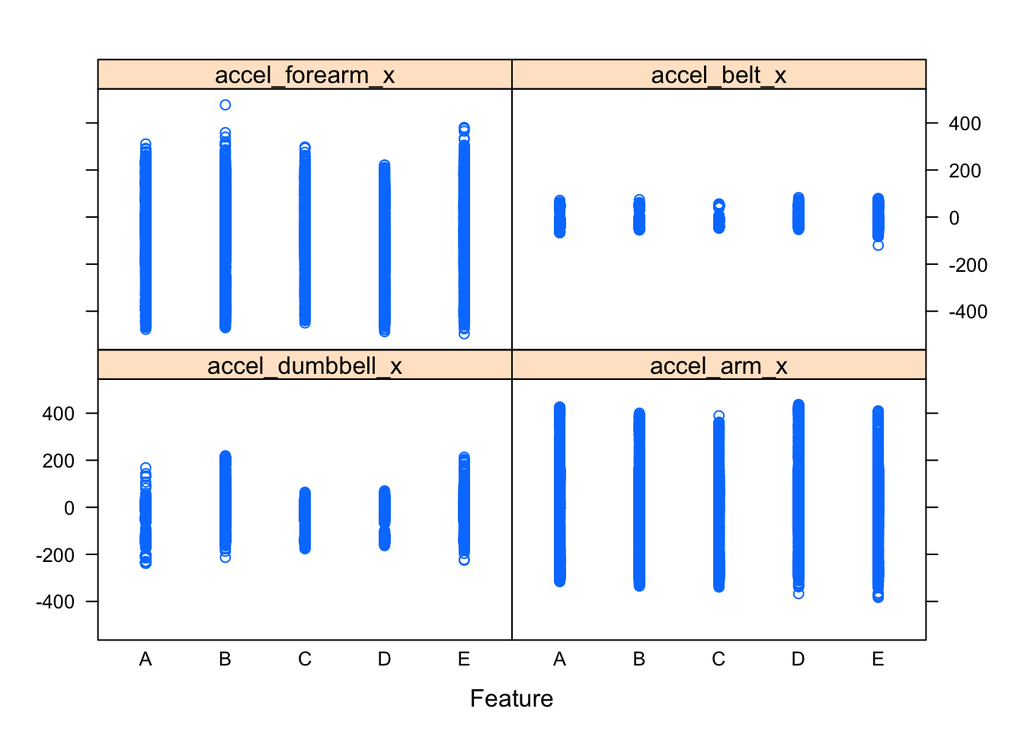

```r
featurePlot(x=pml_trainset[,c("accel_dumbbell_x","accel_arm_x","accel_forearm_x","accel_belt_x")],y=pml_trainset$classe,plot="strip")
```

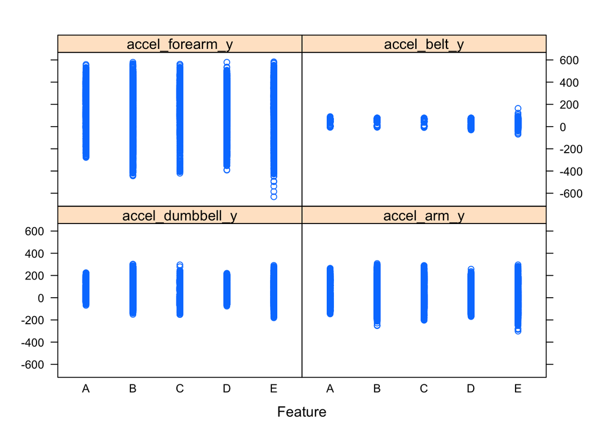

```r
featurePlot(x=pml_trainset[,c("accel_dumbbell_y","accel_arm_y","accel_forearm_y","accel_belt_y")],y=pml_trainset$classe,plot="strip")
```

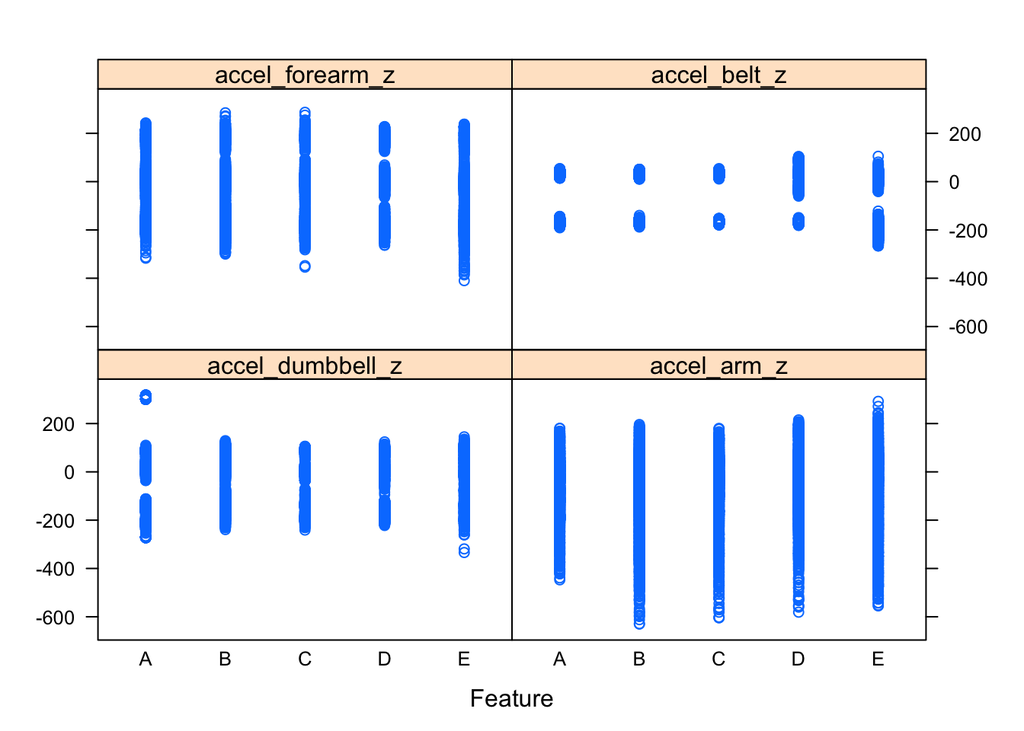

```r
featurePlot(x=pml_trainset[,c("accel_dumbbell_z","accel_arm_z","accel_forearm_z","accel_belt_z")],y=pml_trainset$classe,plot="strip")
```

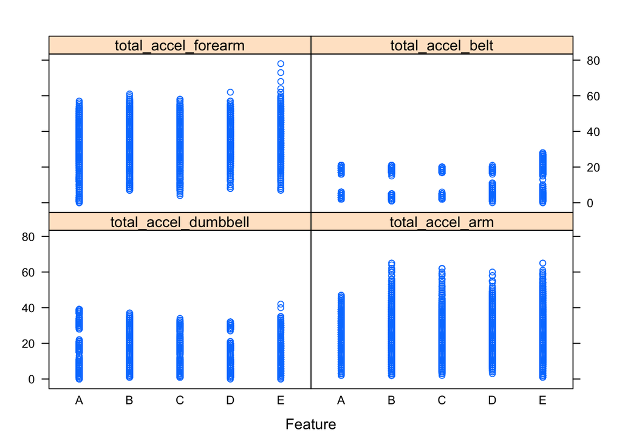

```r
featurePlot(x=pml_trainset[,c("total_accel_dumbbell","total_accel_arm","total_accel_forearm","total_accel_belt")],y=pml_trainset$classe,plot="strip")
```

### Observations

1. There is no readily visible combination of predictors spread patterns that highlights any specific class outcome.
2. However, it is also clear that there are certain distinct patterns of predictor spreads for certain specific outcome classes.
3. The overall impression is that a complex combination of predictor values should be possible that may be sufficiently high in prediction accuracy.

### Try the candidate Models

**First, SVM Model**

```r
mdlfit_svm <- svm(classe ~ ., data=pml_trainset)
predict_svm <- predict(mdlfit_svm,newdata=pml_validset)
confusionMatrix(predict_svm,pml_validset$classe)
```

```
## Confusion Matrix and Statistics
##
##           Reference
## Prediction    A    B    C    D    E
##          A 1960  203  138  158   40
##          B   37 1097   85   21  108
##          C  108  137 1089  109  106
##          D  116   32   37  984   87
##          E   11   49   19   14 1101
##
## Overall Statistics
##
##                Accuracy : 0.7942
##                  95% CI : (0.785, 0.8031)
##     No Information Rate : 0.2845
##     P-Value [Acc > NIR] : < 2.2e-16
##
##                   Kappa : 0.7386
##
##  Mcnemar's Test P-Value : < 2.2e-16
##
## Statistics by Class:
##
##                      Class: A Class: B Class: C Class: D Class: E
## Sensitivity            0.8781   0.7227   0.7961   0.7652   0.7635
## Specificity            0.9040   0.9603   0.9290   0.9585   0.9855
## Pos Pred Value         0.7843   0.8138   0.7030   0.7834   0.9221
## Neg Pred Value         0.9491   0.9352   0.9557   0.9542   0.9487
## Prevalence             0.2845   0.1935   0.1744   0.1639   0.1838
## Detection Rate         0.2498   0.1398   0.1388   0.1254   0.1403
## Detection Prevalence   0.3185   0.1718   0.1974   0.1601   0.1522
## Balanced Accuracy      0.8911   0.8415   0.8625   0.8618   0.8745
```

**CART MODEL**

```r
mdlfit_cart <- train(classe ~., method="rpart",data=pml_trainset)
predict_cart <- predict(mdlfit_cart,newdata=pml_validset)
confusionMatrix(predict_cart,pml_validset$classe)
```

```
## Confusion Matrix and Statistics
##
##           Reference
## Prediction    A    B    C    D    E
##          A 1780  893  973  413  502
##          B   26  264   12   27  178
##          C    0    0    0    0    0
##          D  423  361  383  846  325
##          E    3    0    0    0  437
##
## Overall Statistics
##
##                Accuracy : 0.424
##                  95% CI : (0.4131, 0.4351)
##     No Information Rate : 0.2845
##     P-Value [Acc > NIR] : < 2.2e-16
##
##                   Kappa : 0.2451
##
##  Mcnemar's Test P-Value : NA
##
## Statistics by Class:
##
##                      Class: A Class: B Class: C Class: D Class: E
## Sensitivity            0.7975  0.17391   0.0000   0.6579  0.30305
## Specificity            0.5046  0.96160   1.0000   0.7726  0.99953
## Pos Pred Value         0.3903  0.52071      NaN   0.3618  0.99318
## Neg Pred Value         0.8624  0.82913   0.8256   0.9201  0.86430
## Prevalence             0.2845  0.19347   0.1744   0.1639  0.18379
## Detection Rate         0.2269  0.03365   0.0000   0.1078  0.05570
## Detection Prevalence   0.5813  0.06462   0.0000   0.2980  0.05608
## Balanced Accuracy      0.6511  0.56776   0.5000   0.7152  0.65129
```

**Naive Bayes**

```r
mdlfit_nbayes <- naiveBayes(classe ~.,data=pml_trainset)
predict_nbayes <- predict(mdlfit_nbayes,newdata=pml_validset)
confusionMatrix(predict_nbayes,pml_validset$classe)
```

```
## Confusion Matrix and Statistics
##
##           Reference
## Prediction    A    B    C    D    E
##          A 1232  332  437  370  326
##          B   63  471   82   55  284
##          C  323  176  416  131  108
##          D  494  332  347  627  259
##          E  120  207   86  103  465
##
## Overall Statistics
##
##                Accuracy : 0.4093
##                  95% CI : (0.3983, 0.4202)
##     No Information Rate : 0.2845
##     P-Value [Acc > NIR] : < 2.2e-16
##
##                   Kappa : 0.2494
##
##  Mcnemar's Test P-Value : < 2.2e-16
##
## Statistics by Class:
##
##                      Class: A Class: B Class: C Class: D Class: E
## Sensitivity            0.5520  0.31028  0.30409  0.48756  0.32247
## Specificity            0.7390  0.92351  0.88608  0.78171  0.91943
## Pos Pred Value         0.4568  0.49319  0.36049  0.30452  0.47401
## Neg Pred Value         0.8058  0.84806  0.85774  0.88612  0.85768
## Prevalence             0.2845  0.19347  0.17436  0.16391  0.18379
## Detection Rate         0.1570  0.06003  0.05302  0.07991  0.05927
## Detection Prevalence   0.3437  0.12172  0.14708  0.26243  0.12503
## Balanced Accuracy      0.6455  0.61690  0.59508  0.63463  0.62095
```

**Random Forest**

```r
mdlfit_rf <- randomForest(classe ~., data=pml_trainset)
predict_rf <- predict(mdlfit_rf,newdata=pml_validset)
confusionMatrix(predict_rf,pml_validset$classe)
```

```
## Confusion Matrix and Statistics
##
##           Reference
## Prediction    A    B    C    D    E
##          A 2153   58   29   38    1
##          B   14 1389   40    4   24
##          C   26   50 1279   40   11
##          D   38    7   18 1192   19
##          E    1   14    2   12 1387
##
## Overall Statistics
##
##                Accuracy : 0.9432
##                  95% CI : (0.9378, 0.9482)
##     No Information Rate : 0.2845
##     P-Value [Acc > NIR] : < 2.2e-16
##
##                   Kappa : 0.9281
##
##  Mcnemar's Test P-Value : 6.838e-07
##
## Statistics by Class:
##
##                      Class: A Class: B Class: C Class: D Class: E
## Sensitivity            0.9646   0.9150   0.9349   0.9269   0.9619
## Specificity            0.9776   0.9870   0.9804   0.9875   0.9955
## Pos Pred Value         0.9447   0.9443   0.9097   0.9356   0.9795
## Neg Pred Value         0.9858   0.9798   0.9862   0.9857   0.9914
## Prevalence             0.2845   0.1935   0.1744   0.1639   0.1838
## Detection Rate         0.2744   0.1770   0.1630   0.1519   0.1768
## Detection Prevalence   0.2905   0.1875   0.1792   0.1624   0.1805
## Balanced Accuracy      0.9711   0.9510   0.9577   0.9572   0.9787
```

## Conclusion

1. Random Forest based model yields the higest accuracy of ~ 94%
2. SVM based model yields ~ 80% accuracy
3. Allowing for overfitting, we select Random Forest based model to apply on the test data
4. **Expected Out of Sample Error : This is expected to be ~ 6% or higher allowing for overfitting**

## preparation of test data and predict using RF Model

```r
pmltest_accel <- subset(pmltest_raw,select = grep("accel",names(pmltest_raw)))
pmltest_accel <- pmltest_accel[,-c(2,7,12,17)]
mean(is.na(pmltest_accel))
```

```
## [1] 0
```

```r
predict_test <- predict(mdlfit_rf,newdata=pmltest_accel)
```